# Evaluate the scalability of integrating GEDI and Earth observation data for detecting fire-induced vegetation changes and improving fire emission estimates

## Main idea

- Fire emission models can underestimate emissions due to exclusion of small fires and fixed (biome-specific) combustion completeness factors.

**Hypothesis:** If a model integrating GEDI and EO data can perform well for a specific domain (region of interest), geographical generalization methods could be used to implement that model in different regions. And this model could be used to improve combustion completeness estimation for fire emission models.

**Proposed outcome:** A global model for vegetation structure change evaluation caused by fires.

## Questions I want to answer

- How do fire regimes vary across different biomes globally?
- What are the primary drivers of fire-induced vegetation change in tropical, temperate, boreal, and arid ecosystems?
- How do different satellite data perform in assessing burn severity across ecosystems?
- What are the current methods to improve geographic generalization on Machine Learning models?
- How can you quantify and propagate uncertainty in global vegetation change models?
- What are the best in situ or plot-level datasets for validating vegetation structural metrics globally?

#### *How do fire regimes vary across different biomes globally?*

“Global decline in burned area of grassland, coincident with a small increase in burned forest area” (Zheng et al. 2021)

Hydroclimatic factors, specifically mean annual precipitation (P) and potential evapotranspiration (E0), fundamentally shape the global distribution and potential of wildfires across different biomes by controlling the two most basic conditions necessary for fire: **fuel production** and **fuel dryness** (Boer et al. 2021). These two variables are able to explain 80% of the global variation in the 0.99 quantile of mean annual fractional burned area. The interplay of these two factors leads to a dichotomy of global fire regimes characterized by either fuel production limitations (PL-type fire) or fuel dryness limitations (DL-type fire).

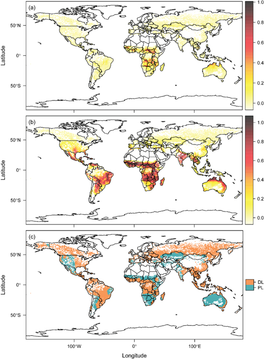

(a) Observed fractional BA. (b) Predicted fractional BA. (c) Production limited vs. Dryness limited fires

The main differences between domains are:

| Feature | Productivity-Limited (PL) Fire Domains | Dryness-Limited (DL) Fire Domains |
| --- | --- | --- |
| **Primary Fire Limitation** | Fuel availability (grass growth) | Fuel dryness (atmospheric moisture demand) |
| **Typical Environment** | Drier environments | Mesic (moderately wet) environments |
| **Main Fuel Type** | Grassy fuels | Woody vegetation and litter fuels |
| **Key Climatic Factor** | Mean annual precipitation (P) | Potential evapotranspiration (E0) and climatic water deficit (D) |
| **Fire Activity Trend** | F0.99 increases with precipitation (P) | F0.99 increases with E0 and D |
| **Common Biomes** | Grasslands, shrublands, barren lands | Forests, wetlands, tundra |
| **Fire Susceptibility** | Limited by fuel production | Limited by fuel drying |

#### *What are the primary drivers of fire-induced vegetation change in tropical, temperate, boreal, and arid ecosystems?*

Fuel moisture and continuity are critical in determining fire regimes. In tropical and boreal ecosystems, moisture levels significantly influence fire occurrence and intensity, with drier conditions promoting more extensive fires (Kelley et al. 2019).

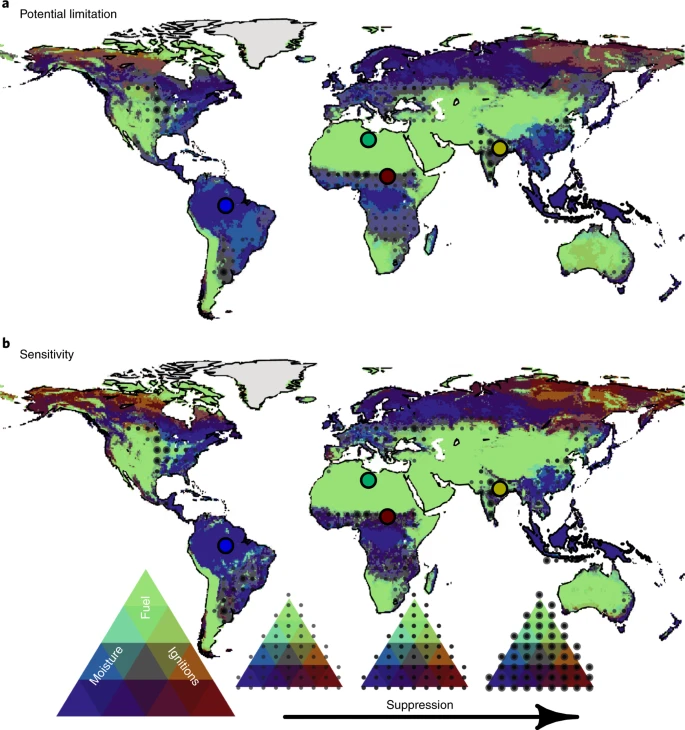

Taken from Kelley et al. (2019)

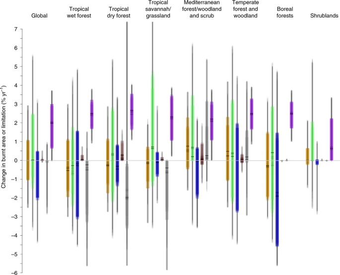

#### *How do different satellite data perform in assessing burn severity across ecosystems?*

The Global Forest Burn Severity (GFBS) dataset, derived from Landsat imagery, provides a 30-meter resolution assessment of burn severity, demonstrating better correlation with ground truth data compared to MODIS datasets.

The Normalized Burn Ratio (NBR) index is widely used for assessing burn severity, with studies showing its effectiveness in differentiating severity levels in various ecosystems

#### *Geographic generalization on Machine Learning models*

##### Location embeddings

The benefit of using location embeddings for geographic generalization lies in their ability to allow machine learning models to learn spatial patterns and relationships inherent in geolocated data. By encoding the location information effectively, models can generalize predictions to new, unseen geographic areas based on the spatial context learned from the training data (Rußwurm et al. 2024).

By capturing implicit characteristics of locations, such as environmental or socioeconomic factors reflected in satellite imagery, location embeddings allow models to make more informed predictions in geographically distant and unseen areas, going beyond simple reliance on spatial proximity (Klemmer et al. 2024).

##### Foundation models (GFZ)

Self-supervised learning + scale make them capable of generalize so well for multiple tasks.

#### *How can you quantify and propagate uncertainty in global vegetation change models?*

#### *What are the best in situ or plot-level datasets for validating remote sensing observations globally?*

Comparison with NFIs in-situ plot data has been done previously. GEDI footprints that were spatially proximate to NFI plots were used to generate probability density curves of relative height distributions and those were compared to the NFI reference plot data.

The Forest Inventory and Analysis program of the USA has over 300,000 sample locations with ground measurements of forest attributes. The data can be accessed here: [FIA datamart](https://research.fs.usda.gov/products/dataandtools/tools/fia-datamart).

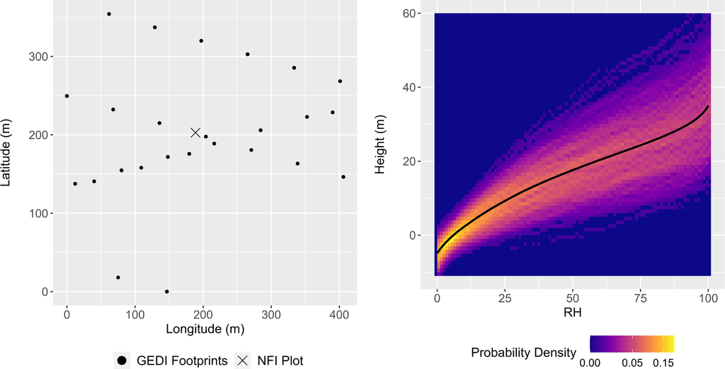

Comparison of GEDI veg. structure metrics with National Forest Inventories

## References

Andela, Niels, Douglas C. Morton, Wilfrid Schroeder, Yang Chen, Paulo M. Brando, and James T. Randerson. 2022. “Tracking and Classifying Amazon Fire Events in Near Real Time.” *Science Advances* 8 (30): eabd2713. https://doi.org/10.1126/sciadv.abd2713.

Boer, Matthias M, Víctor Resco De Dios, Elisa Z Stefaniak, and Ross A Bradstock. 2021. “A Hydroclimatic Model for the Distribution of Fire on Earth.” *Environmental Research Communications* 3 (3): 035001. https://doi.org/10.1088/2515-7620/abec1f.

Kelley, Douglas I., Ioannis Bistinas, Rhys Whitley, Chantelle Burton, Toby R. Marthews, and Ning Dong. 2019. “How Contemporary Bioclimatic and Human Controls Change Global Fire Regimes.” *Nature Climate Change* 9 (9): 690–96. https://doi.org/10.1038/s41558-019-0540-7.

Klemmer, Konstantin, Esther Rolf, Caleb Robinson, Lester Mackey, and Marc Rußwurm. 2024. “SatCLIP: Global, General-Purpose Location Embeddings with Satellite Imagery.” arXiv. http://arxiv.org/abs/2311.17179.

Rußwurm, Marc, Konstantin Klemmer, Esther Rolf, Robin Zbinden, and Devis Tuia. 2024. “Geographic Location Encoding with Spherical Harmonics and Sinusoidal Representation Networks.” arXiv. http://arxiv.org/abs/2310.06743.

Zheng, Bo, Philippe Ciais, Frederic Chevallier, Emilio Chuvieco, Yang Chen, and Hui Yang. 2021. “Increasing Forest Fire Emissions Despite the Decline in Global Burned Area.” *Science Advances* 7 (39): eabh2646. https://doi.org/10.1126/sciadv.abh2646.